# C8 Week 4

JAGV

2026-06-23

# Regularized regression

Basic idea: fit a regression model and penaliza (or shrink) large coefficients.

**Pros**

- Can help with the bias/variance tradeoff
- Can help with model selection

**Cons**

- May be computationally demanding on large data sets
- (In general) Does not perform as well as random forests and boosting.

### A motivating example

Assume the regression model

$$Y = \beta_0 + \beta_1x_1 + \beta_2x_2 + \varepsilon$$

where $x_1$ and $x_2$ are nearly perfectly correlated (co-linear), Then, you can approximate this model by:

$$Y = \beta_0 + \left(\beta_1 + \beta_2\right)x_1 + \varepsilon$$

The result is:

- You will get a good estimate of $Y$.
- The estimate of $Y$ will be biased.
- We may reduce variance in the estimate.

Let’s take a look at one example: `prostate cancer`

```r
prostate <- read.csv("https://web.stanford.edu/~hastie/ElemStatLearn/datasets/prostate.data", sep="\t",head=T,row.names=1)
str(prostate)
```

```
## 'data.frame':    97 obs. of  10 variables:
##  $ lcavol : num  -0.58 -0.994 -0.511 -1.204 0.751 ...
##  $ lweight: num  2.77 3.32 2.69 3.28 3.43 ...
##  $ age    : int  50 58 74 58 62 50 64 58 47 63 ...
##  $ lbph   : num  -1.39 -1.39 -1.39 -1.39 -1.39 ...
##  $ svi    : int  0 0 0 0 0 0 0 0 0 0 ...
##  $ lcp    : num  -1.39 -1.39 -1.39 -1.39 -1.39 ...
##  $ gleason: int  6 6 7 6 6 6 6 6 6 6 ...
##  $ pgg45  : int  0 0 20 0 0 0 0 0 0 0 ...
##  $ lpsa   : num  -0.431 -0.163 -0.163 -0.163 0.372 ...
##  $ train  : logi  TRUE TRUE TRUE TRUE TRUE TRUE ...
```

**Note** the code for this example comes from *Hector Corrada Bravo’s Practical Machine Learning Course* to demonstrate the behaviour of training and test errors, the `prostate` dataset from *Elements of Statistical Learning* is used.

```r
set.seed(1, sample.kind = "Rounding")
```

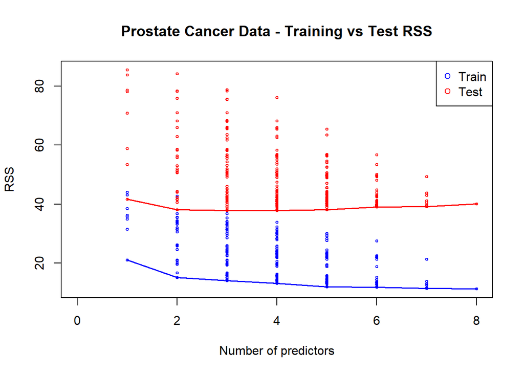

```r
# Define outcome "y" and predictors "x".
covnames <- names(prostate[-(9:10)])
y <- prostate$lpsa
x <- prostate[,covnames]
# Create test set predictors and outcomes.
train.ind <- sample(nrow(prostate), ceiling(nrow(prostate))/2)
y.test <- prostate$lpsa[-train.ind]
x.test <- x[-train.ind,]
# Create training set predictors and outcomes
y <- prostate$lpsa[train.ind]
x <- x[train.ind,]
# Define p, the number of predictors
p <- length(covnames)
# Initialize the list of residual sum squares
rss <- list()
# Loop through each combination of predictors and build models
for (i in 1:p) {
    # Compute matrix for p choose i predictors for i = 1...p (i \times p matrix)
    Index <- combn(p,i)
    # Calculate RSS of each combination of predictors.
    rss[[i]] <- apply(Index, 2, function(is) {
        # Take each combination (or column of Index matrix) and create formula for regression
        form <- as.formula(paste("y~", paste(covnames[is], collapse="+"), sep=""))
        # run LR with combination of predictors on training data
        isfit <- lm(form, data = x)
        # predict outcome for all training data points
        yhat <- predict(isfit)
        # Calculate RSS for predictions on Training data.
        train.rss <- sum((y-yhat)^2)
        # Predict outcome for all test data points
        yhat <- predict(isfit, newdata = x.test)
        # Calculate RSS for predictions on test data
        test.rss <- sum((y.test - yhat)^2)
        # Store each pair of training and test residual sum of squares as a list
        c(train.rss, test.rss)
    })
}

# Set up plot
plot(1:p, 1:p, type = "n", ylim = range(unlist(rss)), xlim = c(0,p),
     xlab = "Number of predictors", ylab = "RSS",
     main = "Prostate Cancer Data - Training vs Test RSS")
# Add data points for training and test RSS
for( i in 1:p) {
    # Plot training residual sum squares in blue
    points(rep(i, ncol(rss[[i]])), rss[[i]][1,], col = "blue", cex = 0.5)
    # Plot test residual sum squares in red
    points(rep(i, ncol(rss[[i]])), rss[[i]][2,], col = "red", cex = 0.5)
}
# Find the minimum training RSS for each combination of predictors
minrss <- sapply(rss, function(x) min(x[1,]))
#Plot line through the minimum training RSS data points in blue
lines((1:p), minrss, col = "blue", lwd = 1.7)
# Find the moinimum test RSS for each combination of predictors
minrss <- sapply(rss, function(x) min(x[2,]))
#Plot line through the minimum test RSS data points in red
lines((1:p), minrss, col = "red", lwd = 1.7)
# Add legend
legend("topright", c("Train", "Test"), col = c("blue", "red"), pch = 1)
```

From here, we can see that the train set error always goes down, whereas the test set error exhibits a typical pattern: it goes down, hit a plateau and then goes back up again. This is because we are overfitting the data in the training set.

## Model selection approach:

### Split samples

No method better when data/computation time permits it. The approach is as follows:

- Divide data into training/test/validation sets
- Treat validation as test data, train all competing models on the trin data and pick the best one on validation
- To appropriately assess performance on new data apply to test set
- You may re-split and reperform steps 1-3

Two common problems

- Limited data
- Computational complexity

### Decomposing expected prediction error

Assume $Y_i = f\left(X_i\right) + \varepsilon_i$, then the expected prediction error is given by $EPE\left(\lambda\right) = E\left[\left\{Y - \hat{f}_{\lambda}\left(X\right)\right\}^2\right]$.

Suppose that $\hat{f}_{\lambda}$ is the estimate from teh training data and look at a new data point $X = x^*$. Then

$$E\left[\left\{Y - \hat{f}_{\lambda}\left(x^+\right)\right\}^2\right]
= \underbrace{\sigma^2}_{\text{Irreducible}} +
\underbrace{\left\{E\left[\hat{f}_{\lambda}\left(x^+\right)\right] -
f\left(x^+\right)\right\}^2}_{\text{Bias}^2} +
\underbrace{var\left[\hat{f}_{\lambda}\left(x_0\right)\right]}_{\text{Variance}}$$

### Hard thresholding

When having less observations (samples) than covariates, the design matrix will be singular. Therefore, as a solution to this, for the model $Y = f\left(X\right) + \varepsilon$ set $\hat{f}_{\lambda}\left(x\right) = x'\beta$ and constrain only $\lambda$ of the coefficients to be nonzero.

Selection problem is after choosing $\lambda$ figure out which $p-\lambda$ coefficients to make nonzero.

#### Regularization for regression

If the $\beta_j$’s are unconstrained:

- They can explode
- And hence are susceptible to very high variance

To control variance, we might regularize/shrink the coefficients

$$PRSS\left(\beta\right) = \sum_{j=1}^{n}{\left(Y -
\sum_{i=1}^{m}{\beta_{1i}X_{ij}}\right)^2} + P\left(\lambda;\beta\right)$$
where $PRSS$ is a penalized form of the sum of squares. Things that are commonly looked for:

- Penalty reduces complexity and variance
- Penalty respects structure of the problem

### Ridge regression

The problem is stated as solving

$$\sum_{i=1}^{N}{\left(y_i - \beta_0 -
\sum_{j=1}^{p}{x_{ij}\beta_j}\right)}^2 + \lambda\sum_{j=1}^{p}\beta_j^2$$
which is equivalent to solving

$$\sum_{i=1}^{N}{\left(y_i - \beta_0 -
\sum_{j=1}^{p}{x_{ij}\beta_j}\right)}^2$$

subject to $\sum_{j=1}^{p}{\beta_j^2} \leq s$ where $s$ is inversely proportional to $\lambda$. Inclusion of $\lambda$ makes the problem non-singular even if $X'X$ is not invertible.

#### Tuning parameter $\lambda$

We can see that $\lambda$ controls the size of the coefficients and the amount of **regularization**. Moreover, as $\lambda\rightarrow 0$, we obtain the LS solution, whereas as $\lambda\rightarrow \infty$ we have $\hat\beta = 0$.

So, taking the parameter can be done with cross-validation or techniques that help to find the optimal tradeoff of bias for variance.

### Regularized Regression - LASSO (Least Absolute Shrinkage and Selection Operator) regression

It is similar to **ridge regression**, with slightly different penalty term:

$$\sum_{i=1}^{N}{\left(y_i - \beta_0 -
\sum_{j=1}^{p}{x_{ij}\beta_j}\right)}^2 +
\lambda\sum_{j=1}^{p}\left|\beta_j\right|$$
which is equivalent to solving

$$\sum_{i=1}^{N}{\left(y_i - \beta_0 -
\sum_{j=1}^{p}{x_{ij}\beta_j}\right)}^2$$

subject to constraint $\sum_{j=1}^{p}{\left|\beta_j\right|} \leq s$ where $s$ is inversely proportional to $\lambda$. **NOTE**: LASSO effectively performs model selection (choose subset of predictors) while shrinking other coefficients, whereas **ridge regression** only shrinks the coefficients.

# Combining predictors

Some key ideas on this topic:

- You can combine classifiers by averaging/voting
- Combining classifiers improves accuracy
- Combining classifiers reduces interpretability
- Boosting, bagging, and random forests are variants on this theme

## Real-life examples.

### Netflix competition

[Netflix Prize](https://web.archive.org/web/20120507052942/http://www.netflixprize.com/leaderboard)

### Heritage health prize - Progress Prize 1

(broken links)

[Market Makers](https://kaggle2.blob.core.windows.net/wiki-files/327/e4cd1d25-eca9-49ca-9593-b254a773fe03/Market%20Makers%20-%20Milestone%201%20Description%20V2%201.pdf)

[Mestrom](https://kaggle2.blob.core.windows.net/wiki-files/327/09ccf652-8c1c-4a3d-b979-ce2369c985e4/Willem%20Mestrom%20-%20Milestone%201%20Description%20V2%202.pdf)

## The basic intuition behind majority vote

Suppose we have 5 completely independent classifiers. If accuracy of each is $70\%$, then, the **majority vote accuracy** (the probability of the majority of the models achieving $70\%$ at the same time) is:

$$\text{Majority vote accuracy, MVA} = \mathbb{P}\left(\text{3
correct, 2 wrong}\right) + \mathbb{P}\left(\text{4 correct, 1
wrong}\right) + \mathbb{P}\left(\text{5 correct}\right)$$

therefore, under the independent assumption, this might be calculated using the binomial distribution. So

**Note**: using 101 classifiers, this quantity becomes $99.9\%$.

The approaches for combining classifiers includes:

- For **similar** classifiers: bagging, boosting and random forests
- For **different** classifiers: model stacking and model ensembling

Let’s take a look at one example: Wage data

```r
library(ISLR)
data(Wage)
library(ggplot2)
library(caret)
Wage <- subset(Wage, select = -c(logwage))

# Create a building data set and validation set

inBuild <- createDataPartition(y = Wage$wage, p = 0.7, list = FALSE)

validation <- Wage[-inBuild, ]
buildData <- Wage[inBuild,]

inTrain <- createDataPartition(y = buildData$wage, p = 0.7, list = FALSE)
training <- buildData[inTrain,]
testing <- buildData[-inTrain,]
```

```r
dim(training)
```

```
## [1] 1474   10
```

```r
dim(testing)
```

```
## [1] 628  10
```

```r
dim(validation)
```

```
## [1] 898  10
```

Build two different models

```r
mod1 <- train(wage ~., method = "glm", data = training)
mod2 <- train(wage ~., method = "rf", data = training, trControl = trainControl(method = "cv"), number = 3)
```

Prediction on the testing set

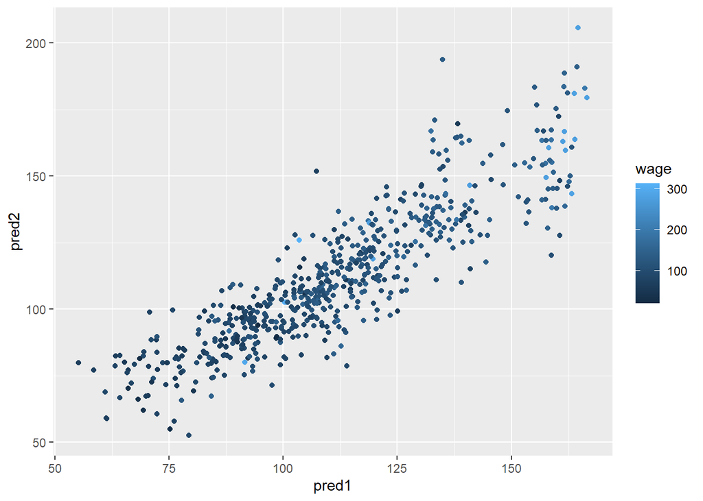

```r
pred1 <- predict(mod1, testing)
pred2 <- predict(mod2, testing)
qplot(pred1,pred2, colour = wage, data = testing)
```

Now, lest fit a model that combines predictors

```r
predF <- data.frame(pred1,pred2, wage = testing$wage)
combModFit <- train(wage ~., method = "gam", data = predF)
combPred <- predict(combModFit, predF)
```

Look at the testing errors

```r
sqrt(sum((pred1 - testing$wage)^2))
```

```
## [1] 889.0509
```

```r
sqrt(sum((pred2 - testing$wage)^2))
```

```
## [1] 907.4626
```

```r
sqrt(sum((combPred - testing$wage)^2))
```

```
## [1] 859.2108
```

Now let’s try it out on the validation set

```r
pred1V <- predict(mod1, validation)
pred2V <- predict(mod2, validation)
predVDF <- data.frame(pred1 = pred1V, pred2 = pred2V)
combPredV <- predict(combModFit, predVDF)
```

Look at the errors on validation

```r
sqrt(sum((pred1V - validation$wage)^2))
```

```
## [1] 1035.738
```

```r
sqrt(sum((pred2V - validation$wage)^2))
```

```
## [1] 1065.801
```

```r
sqrt(sum((combPredV - validation$wage)^2))
```

```
## [1] 1075.302
```

## Final comments

Recall: **scalability matters**: One important point to keep in mind when doing model ensembling is that this can lead to increases in computational complexity. So, it turns out that even though **Netflix has paid a million dollars** to the team that won the prize, **the solution (the millionaire dollar solution) was never actually implemented** because it was too computationaly intensive to apply to specific data sets.

# Forecasting

Let’s talk about forecasting, which is the name used for *predictions* in time series data. Financial data is a kind of time series data, as we can see in the following link: [Google Finance](https://www.google.com/finance/beta)

The main difference is that **data is time-dependent**. Here, we are going to look for some components:

- Trends - long term increase or decrease.
- Seasonal patterns - patterns related to time (week, month, year, etc.)
- Cycles - patterns that rise and fall periodically

Therefore, the approach of *subsampling* into train/test data sets is more complicated. Note: a similar problem arises when dealing with **spatial data** for the same reasons: dependency between nearby observations and location specific effects.

Typically, the goal is to predict one or more observations into the future (which in regression would be **extrapolation**). All standard predictions can be used (with caution/sense!).

Be careful with spurious correlation, as this kxcd joke shows with geographical maps: http://xkcd.com/1138/ (red areas are the high density in population places).

Let’s take a look at an example.

```r
#install.packages("quantmod")
library(quantmod)
from.dat <- as.Date("01/01/08", format = "%m/%d/%y")
to.dat <- as.Date("12/31/13", format = "%m/%d/%y")
getSymbols("GOOG", src = "yahoo", from = from.dat, to = to.dat)
```

```
## [1] "GOOG"
```

```r
head(GOOG)
```

```
##            GOOG.Open GOOG.High GOOG.Low GOOG.Close GOOG.Volume GOOG.Adjusted
## 2008-01-02  17.25707  17.36915 16.87998   17.06578   172921733      16.91664
## 2008-01-03  17.06753  17.10713 16.84984   17.06927   130587647      16.92009
## 2008-01-04  16.92880  16.96043 16.31385   16.36366   215195594      16.22065
## 2008-01-07  16.28745  16.49517 15.87425   16.17064   257096061      16.02931
## 2008-01-08  16.26404  16.43739 15.71609   15.73303   214364490      15.59553
## 2008-01-09  15.69218  16.27251 15.50463   16.26902   270598482      16.12683
```

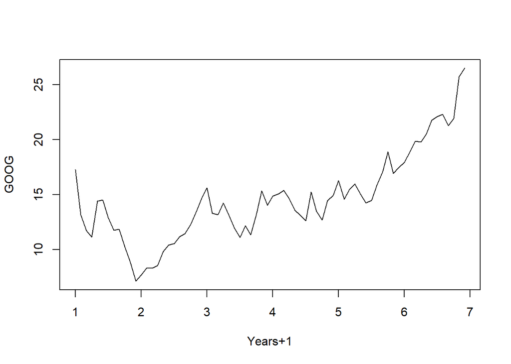

```r
mGoog <- to.monthly(GOOG)
googOpen <- Op(mGoog)
ts1 <- ts(googOpen, frequency = 12)
plot(ts1, xlab = "Years+1", ylab = "GOOG")
```

One way to analyze time series data, is to decompose into:

- **Trend**: Consistently increasing pattern over time.
- **Seasonal**: when there is a pattern over a fixed period of time that recurs.
- **Cyclic**: when data rises and falls over non fixed periods.

We can use the function `decompose` to decompose (duh!) a time series into its parts:

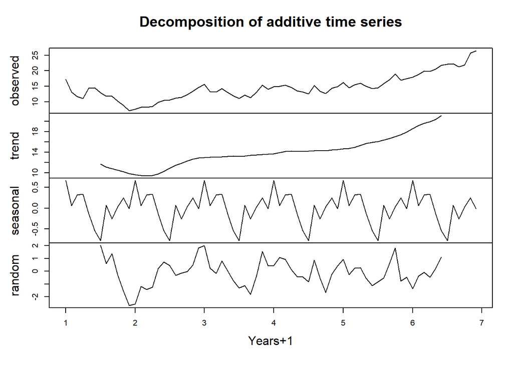

```r
plot(decompose(ts1), xlab = "Years+1")
```

### Training and test sets

```r
ts1Train <- window(ts1, start = 1, end = 5)
ts1Test <- window(ts1, start = 5, end = 7)
ts1Train
```

```
##         Jan       Feb       Mar       Apr       May       Jun       Jul
## 1 17.257067 13.167395 11.743732 11.151701 14.403761 14.508120 12.940994
## 2  7.686190  8.326042  8.302132  8.562406  9.838871 10.429159 10.565398
## 3 15.615220 13.315092 13.180596 14.230411 13.113348 11.965899 11.090679
## 4 14.856315 15.055817 15.386826 14.664036 13.591556 13.151704 12.621193
## 5 16.262545
##         Aug       Sep       Oct       Nov       Dec
## 1 11.768638 11.874741 10.240367  8.906118  7.140237
## 2 11.176607 11.449086 12.278975 13.376860 14.648344
## 3 12.179100 11.332025 13.200521 15.335768 14.022440
## 4 15.223439 13.468268 12.698652 14.448344 14.943986
## 5
```

```r
ts1Test
```

```
##        Jan      Feb      Mar      Apr      May      Jun      Jul      Aug
## 5 16.26254 14.56889 15.49841 15.95943 15.03838 14.24137 14.49118 15.87300
## 6 17.91834 18.88422 19.87052 19.80103 20.50464 21.74350 22.07849 22.29145
##        Sep      Oct      Nov      Dec
## 5 17.04984 18.90539 16.92406 17.49044
## 6 21.27924 21.92407 25.69843 26.48846
```

## Forecasting with simple moving average.

$$\hat{Y}_t = \dfrac{1}{2k+1}\sum_{j = -k}^{k}{Y_{t+j}}$$

This is a moving average of order $k$, centered.

```r
# install.packages("forecast")
library(forecast)
```

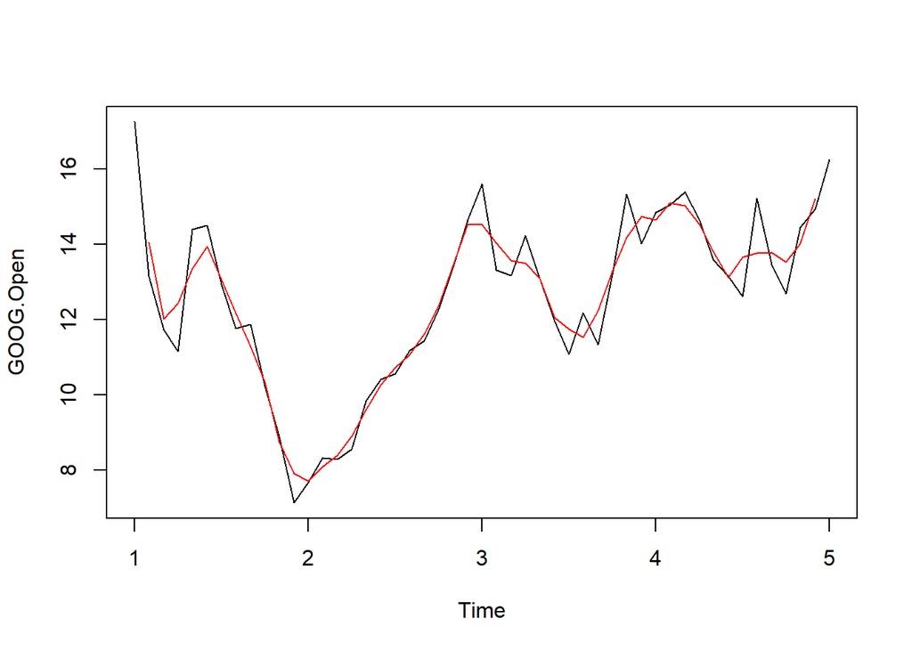

```r
plot(ts1Train)
lines(ma(ts1Train, order = 3), col = "red")
```

## Forecasting with exponential smoothing

Simple exponential smoothing.

$$\hat{Y}_{t+1} = \alpha Y_t + \left(1-\alpha) \hat{Y}_t$$

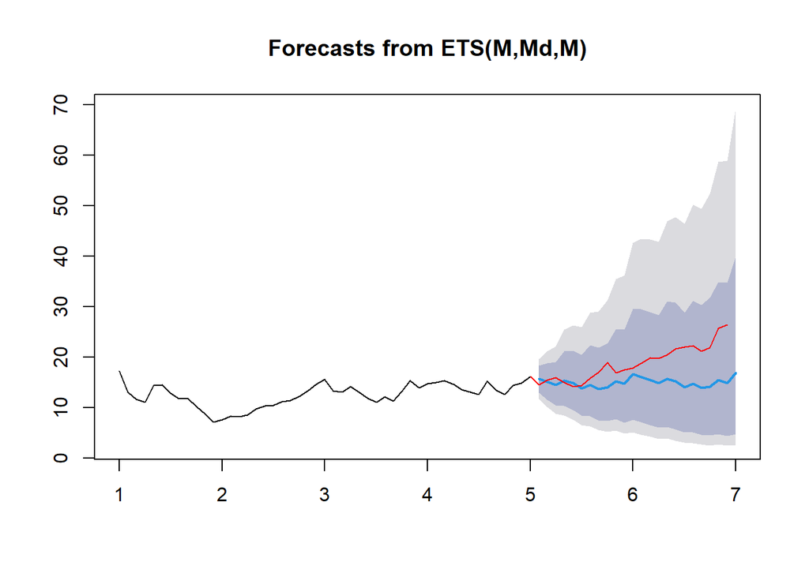

```r
ets1 <- ets(ts1Train, model = "MMM")
fcast <- forecast(ets1)
plot(fcast)
lines(ts1Test, col = "red")
```

```r
accuracy(fcast, ts1Test)
```

```
##                      ME     RMSE      MAE        MPE      MAPE      MASE
## Training set 0.08120558 1.319649 1.045117  0.2587937  8.345366 0.3980114
## Test set     3.94306891 5.264749 4.138580 18.3572757 19.701803 1.5760935
##                     ACF1 Theil's U
## Training set -0.01693586        NA
## Test set      0.76456067  3.821253
```

# Unsupervised prediction

Supervised prediction is regarded as prediction where you know what the labels are. Unsupervised prediction is when you do not know the labels for prediction. In those cases, to build a predictor you

- Create clusters
- Name clusters
- Build predictor for clusters

so that, in a new data set, you predict clusters

## Iris data set example

```r
data(iris)
library(ggplot2)
library(caret)
inTrain <- createDataPartition(y = iris$Species, p = 0.7, list = FALSE)

training <- iris[inTrain,]
testing <- iris[-inTrain,]
dim(training)
```

```
## [1] 105   5
```

```r
dim(testing)
```

```
## [1] 45  5
```

## Cluster with k-means

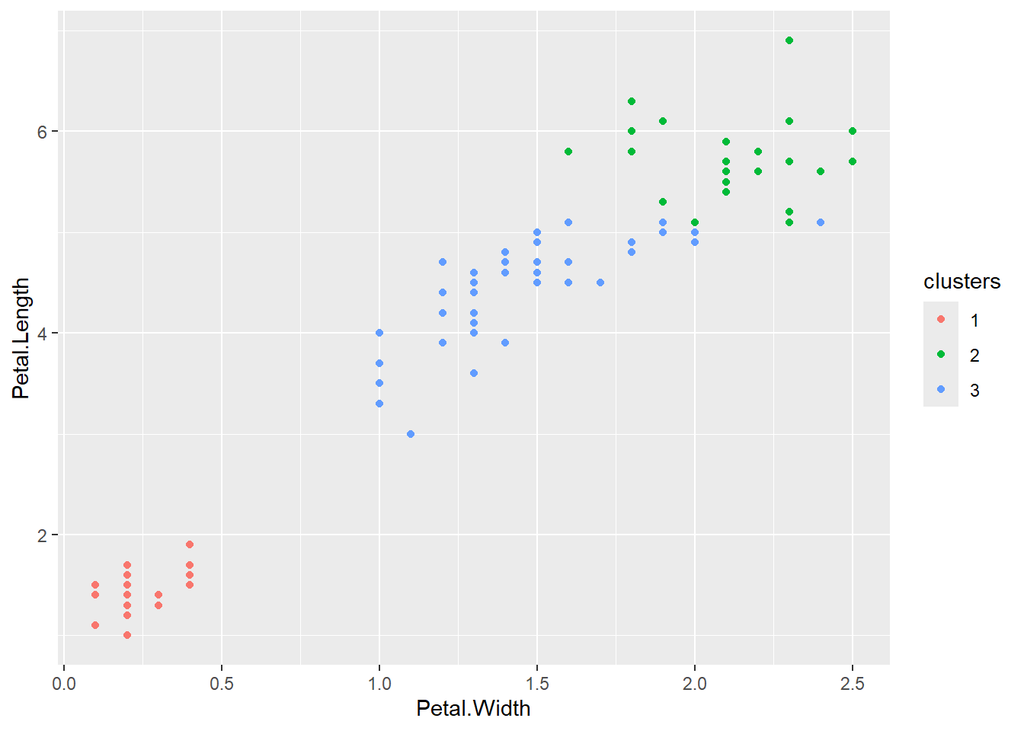

```r
kMeans1 <- kmeans(subset(training, select = -c(Species)), centers = 3)
training$clusters <- as.factor(kMeans1$cluster)
qplot(Petal.Width, Petal.Length, colour = clusters, data = training)
```

In this case, the clusters are closely related to the Species, but this is in general not the case. We can compare those clusters against the real labels

```r
table(kMeans1$cluster, training$Species)
```

```
##
##     setosa versicolor virginica
##   1     35          0         0
##   2      0          2        23
##   3      0         33        12
```

### Build a predictor

```r
modFit <- train(clusters ~., data = subset(training, select = -c(Species)), method = "rpart")
table(predict(modFit, training), training$Species)
```

```
##
##     setosa versicolor virginica
##   1     35          0         0
##   2      0          0        21
##   3      0         35        14
```

### Apply on a test set

```r
table(predict(modFit, testing), testing$Species)
```

```
##
##     setosa versicolor virginica
##   1     15          0         0
##   2      0          0        13
##   3      0         15         2
```